# Symmetry on Average

Chaos **and** Randomness

## The Central Idea

A single chaotic trajectory cannot be periodic, so it cannot possess a non-trivial symmetry. Yet when we look at the *density* of a long orbit (or the attractor itself), clear symmetry often appears. This is “symmetry on average”—the phenomenon explored in Field & Golubitsky’s *Symmetric Chaos*.

The mechanism is simple: iterate a map that *commutes* with a symmetry group (an equivariant map). The attractor is then invariant under that group.

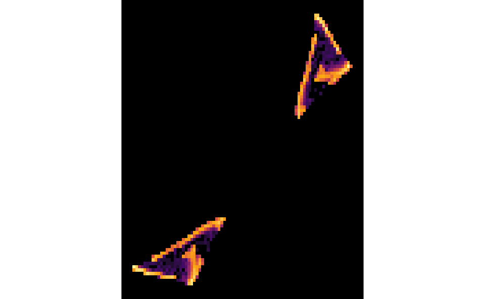

```r
# Field–Golubitsky style map tuned for visible structure (not a solid disk)
icon <- function(z, lambda = -1.8, alpha = 2.0, gamma = 1.0, m = 5) {
  r2 <- Mod(z)^2
  (lambda + alpha * r2) * z + gamma * Conj(z)^(m - 1)
}

n <- 150000
z <- 0.1 + 0.3i
pts <- complex(n)
for (i in 1:n) {
  z <- icon(z)
  pts[i] <- z
}
pts <- pts[-(1:2000)] # discard transient
pts <- pts[abs(pts) < 2] # keep only the attractor region

df <- data.frame(x = Re(pts), y = Im(pts))

ggplot(df, aes(x, y)) +
  stat_bin2d(bins = 80) +
  scale_fill_viridis_c(option = "inferno", trans = "log10", na.value = "black") +
  coord_fixed() +
  theme_void() +
  theme(
    legend.position = "none",
    plot.background = element_rect(fill = "black", color = NA)
  )
```

## Chaos Game as a Special Case

### Density version of the Sierpinski chaos game

[figure not shown]

Visit-frequency coloring of the chaos game

```r
vertices <- matrix(c(0, 0, 1, 0, 0.5, sqrt(3) / 2), ncol = 2, byrow = TRUE)
n <- 60000
pts <- matrix(0, n, 2)
pts[1, ] <- c(0.5, 0.3)
for (i in 2:n) {
  v <- vertices[sample(3, 1), ]
  pts[i, ] <- (pts[i - 1, ] + v) / 2
}
df <- as.data.frame(pts[-c(1:300), ])
names(df) <- c("x", "y")

ggplot(df, aes(x, y)) +
  stat_bin2d(bins = 90) +
  scale_fill_viridis_c(option = "magma", trans = "log10", na.value = "white") +
  coord_fixed() +
  theme_void() +
  theme(legend.position = "none")
```

## Design Implications for Art Students

- **Equivariance is the design constraint**: write (or choose) a rule that treats symmetric points the same way. The long-term picture will automatically be symmetric.
- **Color = density**: the aesthetic decisions move to palette, contrast, and which regions you emphasize—exactly as in the Field–Golubitsky images.
- **Parameters are knobs**: small changes in coefficients produce continuous families of related symmetric designs. This is parametric generative art with a mathematical guarantee of symmetry.
- **From instantaneous to average**: the same idea appears in physical systems (Faraday waves, etc.). A single frame may look noisy; the time average reveals the symmetry.

## Minimal working formula

(with optional small imaginary term ( iz ) to break pure reflection symmetry and obtain pure rotational symmetry).

Iterate from a random start, discard the first thousand points, and color by visit count. That is the entire pipeline from the 1995 paper, reduced to a few lines of code.